# Statistics: The Science of Decisions Project Instructions

## Background

In a Stroop task, participants are presented with a list of words, with each word displayed in a color of ink. The participant’s task is to say out loud the color of the ink in which the word is printed. The task has two conditions: a congruent words condition, and an incongruent words condition. In the congruent words condition, the words being displayed are color words whose names match the colors in which they are printed: for example RED , BLUE . In the incongruent words condition, the words displayed are color words whose names do not match the colors in which they are printed: for example PURPLE , ORANGE . In each case, we measure the time it takes to name the ink colors in equallysized lists. Each participant will go through and record a time from each condition.

## Questions For Investigation

### 1 What is our independent variable? What is our dependent variable?

The independent variable is the congruent words condition(congruent/incongruent) The dependent variable is the time it takes to name the ink colors.

### 2 What is an appropriate set of hypotheses for this task? What kind of statistical test do you expect to perform? Justify your choices

Null hypotheses(H0): $\mu_{C}$=$\mu_{I}$

Alternative hypotheses(Ha): $\mu_{C}\not=\mu_{I}$

$\mu_C$ is the population average time to name the ink under CONGRUENT condition. $\mu_I$ is the population average time to name the color under INCONGRUENT condition. The null hypotheses assumes there is no difference in the population average time to name the color between congruent condition and incongruent condition. Alternative hypotheses assumes the population average time to name the color is different between congruent condition and incongruent condition.

A two-tailed dependent t-test will be performed. 1. The populaiton parameters are unknown, so it's t-test. 2. The population average time it takes for the incongruent condition could be longer or shorter, so it's two-tailed. 3. Participants go through both condition, so it's dependent.

### 3 Report some descriptive statistics regarding this dataset. Include at least one measure of central tendency and at least one measure of variability.

import the data

```r
data = read.csv('stroopdata.csv')
```

```r
summary(data)
```

```
   Congruent      Incongruent
 Min.   : 8.63   Min.   :15.69
 1st Qu.:11.90   1st Qu.:18.72
 Median :14.36   Median :21.02
 Mean   :14.05   Mean   :22.02
 3rd Qu.:16.20   3rd Qu.:24.05
 Max.   :22.33   Max.   :35.26
```

```r
sd(data$Congruent)
```

3.5593579576452

```r
sd(data$Incongruent)
```

4.79705712246914

The participants in the congruent condition takes an average of 14.05s to name the color, with a standard deviation of 3.56s. In the incongruent condition, it takes an average of 22.02s to name the color, with a standard deviation of 4.80s.

### 4 Provide one or two visualizations that show the distribution of the sample data. Write one or two sentences noting what you observe about the plot or plots.

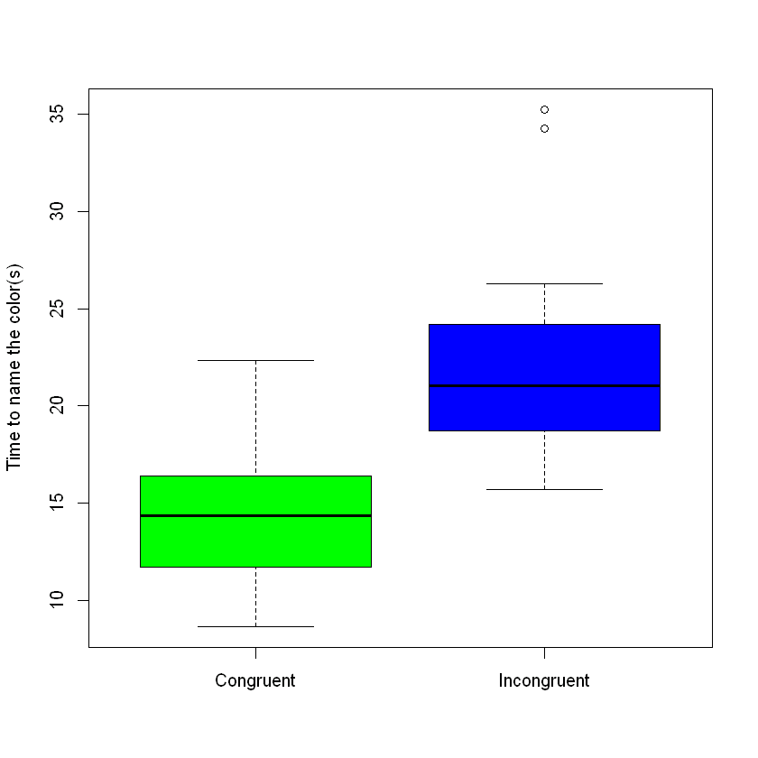

```r
boxplot(data$Congruent,data$Incongruent,col=c("green","blue"),names=c("Congruent","Incongruent"), ylab = "Time to name the color(s)")
```

Participants under the incongruent condition take longer time in average to name the color than under the congruent condition. Under incongruent condition, there are two outliers above the general response time, where participants take especially long time to tell the color.

### 5 Now, perform the statistical test and report your results. What is your confidence level and your critical statistic value? Do you reject the null hypothesis or fail to reject it? Come to a conclusion in terms of the experiment task. Did the results match up with your expectations

```r
t.test(data$Congruent, data$Incongruent, paired = TRUE)
```

```
	Paired t-test

data:  data$Congruent and data$Incongruent
t = -8.0207, df = 23, p-value = 4.103e-08
alternative hypothesis: true difference in means is not equal to 0
95 percent confidence interval:
 -10.019028  -5.910555
sample estimates:
mean of the differences
              -7.964792
```

The confidnece level is chosen to be 95%. Df =23, the t-critical values are -2.069, 2.069. The t-value from the sample is -8.021, less than the critical value of -2.069. And the p-value is 4.10e-08, which means the probability of the H0 is quite low. Therefor we reject the null hypothesis and comes to the conclusion that the population average time to name the color under incongruent condition is longer than under congruent condition. The results matches my expectation. Since it's reasonable that brain will take extra time to deal with the confusion from incongruent.

### 6 Optional: What do you think is responsible for the effects observed? Can you think of an alternative or similar task that would result in a similar effect? Some research about the problem will be helpful for thinking about these two questions!

Different models could explain the effect, like automaticity model, speed of processing model or parallel distributed model. I would prefer the first one. According to the theory, reading is an automatic process, where people see the meaning of words without consciousness. While naming colors is not automatic. It requires more effort than reading, thus creating interference with the meaning of the words. A similar experiment is conducted with digits. It was found that people take longer time to compare digits when size and value are incompatible (e.g., large 3 small 5) than the case when size and value matches (e.g., large 5 small 3).

### Reference

https://www.rit.edu/cla/gssp400/sbackground.html

https://faculty.washington.edu/chudler/words.html

https://en.wikipedia.org/wiki/Numerical_Stroop_effect